# Working with USGS Data and Functions

Juli Scamardo

2019-10-11

# Working with USGS data

## Download USGS data using dataRetrieval

#### Non function oriented method

```r
lincoln_q <- readNWISdv('06752260', parameterCd = '00060',
                        startDate = '1975-10-01',endDate = '2019-10-01') %>%
  rename(q_cfs = X_00060_00003,
         q_cd = X_00060_00003_cd) %>%
  mutate(site = 'lincoln')

#summary(lincoln_q)

elc_q <- readNWISdv('06752280', parameterCd = '00060',
                        startDate = '1975-10-01',endDate = '2019-10-01') %>%
  rename(q_cfs = X_00060_00003,
         q_cd = X_00060_00003_cd) %>%
  mutate(site = 'elc')


combo_data <- bind_rows(lincoln_q,elc_q)
summary(combo_data)
#summary(elc_q)
```

#### Function oriented method

```r
q_downloader <- function(site_no = '06752260',
                         site_id = 'lincoln'){
  df <- readNWISdv(site_no,
                   parameterCd = '00060',
                   startDate = '1950-10-01',
                   endDate = '2019-10-01') %>%
  rename(q_cfs = X_00060_00003,
         q_cd = X_00060_00003_cd) %>%
    mutate(site = site_id)
  return(df)
}


lincoln_q <- q_downloader(site_no = '06752260',
                          site_id = 'lincoln')
elc_q <- q_downloader(site_no = '06752280',
                      site_id = 'elc')
#
combo_data <- bind_rows(lincoln_q,elc_q)

summary(combo_data)
```

```
##   agency_cd           site_no               Date
##  Length:30858       Length:30858       Min.   :1975-04-08
##  Class :character   Class :character   1st Qu.:1988-01-25
##  Mode  :character   Mode  :character   Median :1998-08-17
##                                        Mean   :1998-07-26
##                                        3rd Qu.:2009-03-09
##                                        Max.   :2019-10-01
##      q_cfs             q_cd               site
##  Min.   :   0.00   Length:30858       Length:30858
##  1st Qu.:   5.36   Class :character   Class :character
##  Median :  25.00   Mode  :character   Mode  :character
##  Mean   : 167.20
##  3rd Qu.: 105.00
##  Max.   :7150.00
```

## Plot the discharge data

#### Time series (xaxis = date)

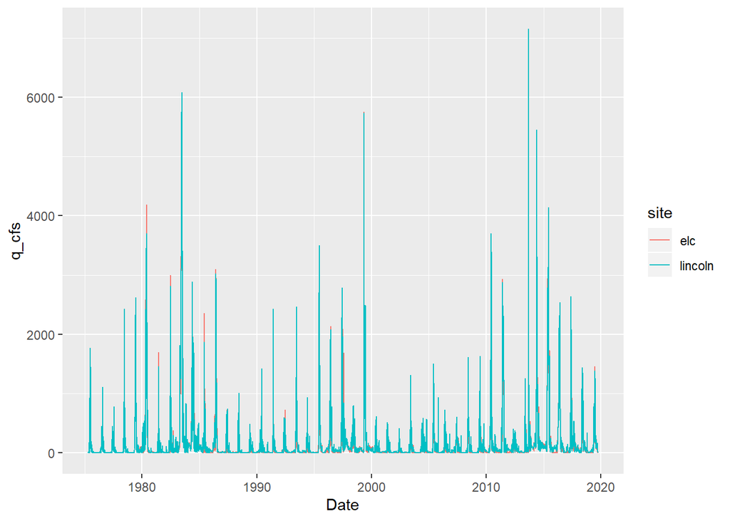

```r
ggplot(combo_data,aes(x=Date,y=q_cfs,color=site)) +
  geom_line()
```

#### Density plot

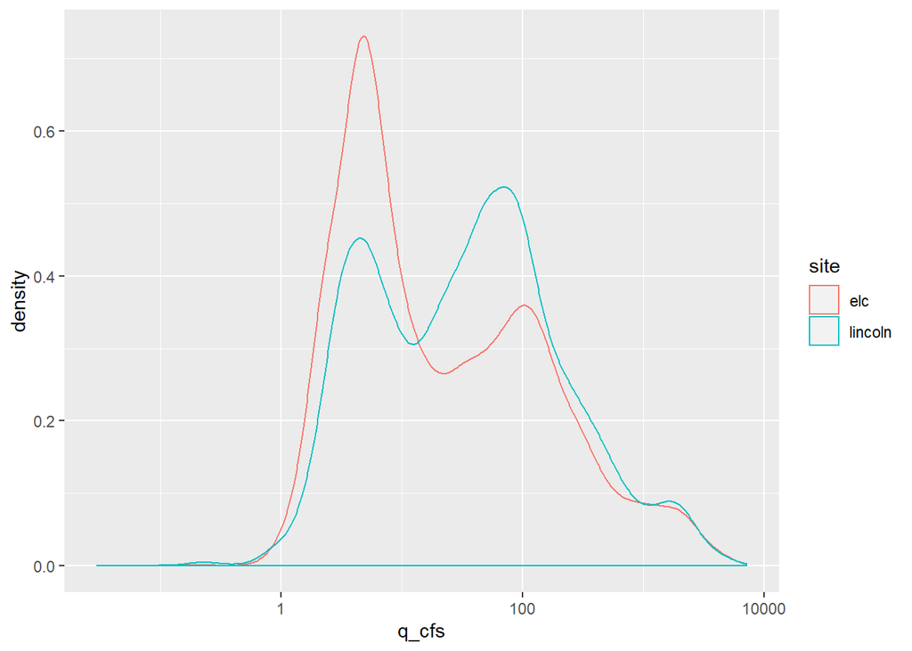

```r
ggplot(combo_data,aes(x=q_cfs,color=site)) +
  geom_density() +
  scale_x_log10()
```

#### Interactive graphs

```r
#Structore examination
#str(combo_data)
wide_data <- combo_data %>%
  select(-agency_cd,-site_no,-q_cd) %>%
  spread(key=site,value=q_cfs)

wide_xts <- xts(wide_data %>%
                  select(elc,lincoln),
                order.by = wide_data$Date)

dygraph(wide_xts)
```

#### Function for interactive graph

```r
xts_maker <- function(df){
  wide_data <- df %>%
    select(-agency_cd,-site_no,-q_cd) %>%
    spread(key=site,value = q_cfs)

  wide_xts <- xts(wide_data %>%
                  select(-Date),
                order.by = wide_data$Date)

  return(wide_xts)

}


wide_xts <- xts_maker(combo_data)
wide_elc <- xts_maker(elc_q)


dygraph(wide_xts)
```

[interactive chart not shown]

```r
dygraph(wide_elc)
```

[interactive chart not shown]

# In class work

## Write a function that makes ggplot time series graph of discharge

Here I want you to write your own function that adds custom themes to your normal ggplot call (so you don’t have to write out theme_few and theme(legend.position = …)) over and over again. You may need to load the library `ggthemes`.

This function call should generate a clean time series plot with a single command and a single option (which data frame to plot). Please plot the `combo_data` dataset here.

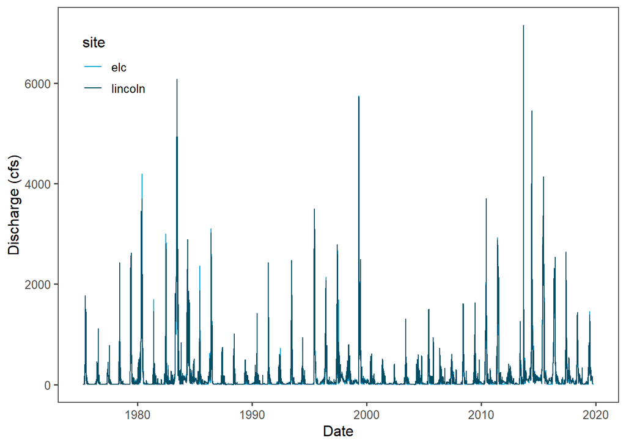

```r
## Create function that plots time series in ggplot2
plot_ts <- function(df){
  p <- ggplot(data = df, aes(x = Date, y = q_cfs, color = site))+
    geom_line() +
    theme_few() +
    scale_color_economist() +
    labs(x = 'Date', y = 'Discharge (cfs)') +
    theme(legend.position = c(0.1, 0.85))

  return(p)
}

## plot combo data using function above
plot_ts(combo_data)
```

## Download discharge data

Here, I downloaded data for the Rio Grande River through Big Bend National Park. I’m looking at 2 USGS gages: one upstream at Castolon and one downstream at Rio Grande Village. These two gages bracket streamflow through Big Bend.

The ‘q_downloader’ function worked for this download, but **‘q_downloader’ could be brittle because certain variable names and values are hard coded. Some sites many not follow this naming scheme.**

```r
## Downloading data for Rio Grande near Castolon Visitors Center
castolon <- q_downloader(site_no = '08374550',
                         site_id = 'castolon')

## Downloading data for Rio Grande near Rio Grande Village
rgvillage <- q_downloader(site_no = '08375300',
                          site_id = 'rgvillage')
```

## Joining your two datasets

My goal was to join the two datasets in a way that results in a wide dataset that can be converted to a time series and interactive graph.

```r
## function for joining discharge datasets resulting in a wide dataset
q_join <- function(df1, df2) {

  # gather site name of both sites
  name1<- sym(df1$site[nrow(df1)])
  name2<- sym(df2$site[nrow(df2)])

  # join datasets and rename columns
  q <- full_join(df1, df2, by = 'Date') %>%
    select(agency_cd.x, site_no.x, site_no.y, Date, q_cfs.x, q_cfs.y) %>%
    rename(agency_cd = 1, site_no_1 = 2, site_no_2 = 3, date = 4,
           !!name1 := 5, !!name2 :=6)

return(q)
}

## Creating a wide dataset for streamflow through Big Bend NP
bbnp <- q_join(df1 = castolon, df2 = rgvillage)

## Looking at the top of the dataset to see if it joined correctly
head(bbnp)
```

```
##   agency_cd site_no_1 site_no_2       date castolon rgvillage
## 1      USGS  08374550  08375300 2007-08-03    10000      4840
## 2      USGS  08374550  08375300 2007-08-04     7560      6570
## 3      USGS  08374550  08375300 2007-08-05     3160      5100
## 4      USGS  08374550  08375300 2007-08-06     2350      2160
## 5      USGS  08374550  08375300 2007-08-07     2920      1720
## 6      USGS  08374550  08375300 2007-08-08     1750      1960
```

## Plotting the data

The dataset created above can then be plotted as an interactive graph using dygraphs. Here, I created a function that formats the data into a time series and then plots it.

```r
## Function for formatting and plotting discharge time series
dy_builder <- function(df, title){
  # slim down df
  w <- df %>%
    select(-agency_cd,-contains("site_no"))

  # create time series
  w_xts <- xts(w %>% select(-date), order.by = w$date)

  # plot on interactive map
  g <- dygraph(w_xts, main = title, ylab = 'discharge (cfs)') %>%
    dyOptions(colors = colorspace::diverge_hcl(2))

  return(g)
}

## Plot the bbnp data using the function
dy_builder(bbnp, 'Rio Grande Streamflow: Big Bend NP')
```

[interactive chart not shown]